# Harbour Seal Diet Proportion Models

Author

Max Lindmark & Monica Mion

Published

May 20, 2026

## Purpose

This notebook follows the `sdmTMB` zero-one-inflated beta vignette: https://sdmtmb.github.io/sdmTMB/articles/zoib.html

Here the response is **diet proportion within an individual seal**.

The workflow is:

- keep the same filtered sample base as the earlier diet scripts,
- use `prey_species_lat` as the taxonomic label throughout,
- first inspect all taxa and their relative biomass contribution,
- keep taxa with relative biomass above 5%,
- aggregate the remaining low-contribution taxa into `Other`,
- fit the three ZOIB sub-models separately,
- compare simple and slightly more complex sub-models with AIC.

```r
library(dplyr)
library(tidyr)
library(readr)
library(ggplot2)
library(forcats)
library(janitor)
library(sf)
library(sdmTMB)
library(ggsidekick)
library(rnaturalearth)

theme_set(theme_sleek())

home <- here::here()

biomass_file <- file.path(home, "Data", "HS_SKAG_estimated_abundance_biomass_130426.csv")

# These settings keep the same sample base as the other diet scripts.
colony_keep <- c("Koster", "Väderöarna", "Lysekil", "Marstrand", "Onsala")
method_keep <- c("Faeces", "Hunt")
analysis_year_min <- 2013L

# Keep taxa with relative biomass above this threshold.
# Everything else is grouped into Other.
relative_biomass_threshold <- 0.05

# Focus the spatial maps on cod and herring.
map_taxa <- c("Gadus morhua", "Clupea harengus")

# Match the finer mesh and prediction grid idea used in 03b.
mesh_cutoff_km <- 0.5
map_cell_width_km <- 0.5
```

## Read and clean the raw data

This section reads the file once and cleans the key columns we need later.

```r
# Read the biomass file and clean the main columns used in the analysis.
diet_raw <- read_csv(biomass_file, show_col_types = FALSE) |>
  clean_names() |>
  mutate(
    year = suppressWarnings(as.integer(year)),
    month = suppressWarnings(as.integer(month)),
    quarter = suppressWarnings(as.integer(quarter)),
    latitude = suppressWarnings(as.numeric(latitude)),
    longitude = suppressWarnings(as.numeric(longitude)),

    # Standardize colony names so the same colony is not split across spellings.
    colony = case_when(
      grepl("der.*arna", colony, ignore.case = TRUE) ~ "Väderöarna",
      grepl("^Hallands.*der", colony, ignore.case = TRUE) ~ "Hallands Väderö",
      TRUE ~ as.character(colony)
    ),

    # Standardize sampling type and taxon labels.
    collection_method = as.character(collection_method),
    collection_method = if_else(is.na(collection_method) | collection_method == "", "Unknown", collection_method),
    prey_species_lat = if_else(
      is.na(prey_species_lat) | prey_species_lat == "",
      "Unknown",
      as.character(prey_species_lat)
    ),

    # Fill quarter from month when quarter is missing.
    quarter = coalesce(quarter, ((month - 1L) %/% 3L) + 1L)
  )

# Keep one row per sample for the metadata table.
# This is the table used to decide which samples are part of the analysis.
sample_meta_all <- diet_raw |>
  filter(!is.na(sample_id), !is.na(year), !is.na(latitude), !is.na(longitude)) |>
  distinct(sample_id, .keep_all = TRUE) |>
  transmute(
    sample_id,
    year,
    month,
    quarter,
    lat = latitude,
    lon = longitude,
    collection_method,
    colony
  )

# Aggregate raw prey rows to sample x taxon.
# At this point the taxon is always prey_species_lat.
diet_rows_all <- diet_raw |>
  filter(
    !is.na(sample_id),
    !is.na(biomass_not_corrected),
    !is.na(prey_species_lat),
    prey_species_lat != "",
    tolower(prey_species_lat) != "non prey item",
    prey_species_lat != "Unknown"
  ) |>
  transmute(
    sample_id,
    taxon = prey_species_lat,
    biomass_kg = biomass_not_corrected / 1000
  ) |>
  summarise(biomass_kg = sum(biomass_kg, na.rm = TRUE), .by = c(sample_id, taxon))

# Calculate total biomass per seal/sample.
sample_totals_all <- diet_rows_all |>
  summarise(sum_biomass_kg = sum(biomass_kg, na.rm = TRUE), .by = sample_id)

# Keep only the samples used in the main analysis.
sample_meta_filtered <- sample_meta_all |>
  left_join(sample_totals_all, by = "sample_id") |>
  mutate(sum_biomass_kg = coalesce(sum_biomass_kg, 0)) |>
  filter(
    collection_method %in% method_keep,
    colony %in% colony_keep,
    sum_biomass_kg > 0
  )

if (nrow(sample_meta_filtered) == 0) {
  stop("No samples remain after filtering by colony, method, and positive total biomass.")
}

# Restrict to the main analysis period.
analysis_year_max <- max(sample_meta_filtered$year, na.rm = TRUE)

sample_meta_main <- sample_meta_filtered |>
  filter(year >= analysis_year_min, year <= analysis_year_max)

# Keep only prey rows from those retained samples.
diet_rows_main <- diet_rows_all |>
  semi_join(sample_meta_main, by = "sample_id")

# A quick summary of the retained sample base.
sample_meta_main |>
  summarise(
    n_samples = n_distinct(sample_id),
    min_year = min(year),
    max_year = max(year),
    n_faeces = sum(collection_method == "Faeces"),
    n_hunt = sum(collection_method == "Hunt")
  )
```

```
# A tibble: 1 x 5
  n_samples min_year max_year n_faeces n_hunt
      <int>    <int>    <int>    <int>  <int>
1       829     2013     2025      428    401
```

## Inspect all taxa before aggregation

This section answers: which `prey_species_lat` labels contribute most of the biomass?

```r
# Sum biomass over all retained samples for each taxon.
taxon_support_all <- diet_rows_main |>
  summarise(
    total_biomass_kg = sum(biomass_kg, na.rm = TRUE),
    n_samples_present = n_distinct(sample_id),
    .by = taxon
  ) |>
  arrange(desc(total_biomass_kg)) |>
  mutate(
    relative_biomass = total_biomass_kg / sum(total_biomass_kg),
    cumulative_biomass = cumsum(relative_biomass)
  )

# Keep only taxa that contribute more than 5% of the total biomass.
taxon_keep <- taxon_support_all |>
  filter(relative_biomass > relative_biomass_threshold) |>
  pull(taxon)

taxon_support_all
```

```
# A tibble: 61 x 5
   taxon  total_biomass_kg n_samples_present relative_biomass cumulative_biomass
   <chr>             <dbl>             <int>            <dbl>              <dbl>
 1 Clupe~             92.2               358           0.174               0.174
 2 Gadus~             65.8               208           0.124               0.298
 3 Merla~             54.9               263           0.104               0.402
 4 Pleur~             40.3               137           0.0761              0.478
 5 Polla~             36.8               133           0.0695              0.548
 6 Gadid~             35.5               286           0.0670              0.615
 7 Sprat~             20.2               138           0.0382              0.653
 8 Belon~             18.3                36           0.0346              0.688
 9 Gobiu~             17.4               102           0.0328              0.721
10 Plati~             16.6                50           0.0314              0.752
# i 51 more rows
```

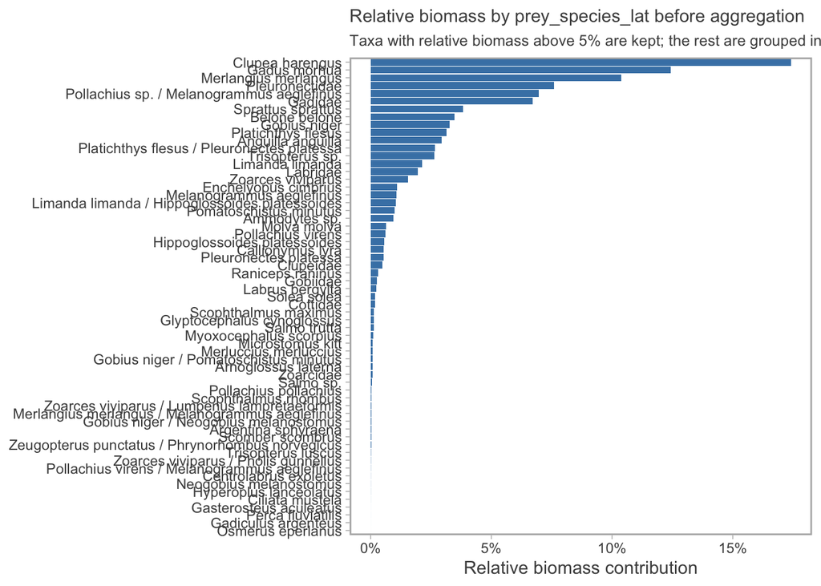

```r
# Plot all prey_species_lat labels before aggregation.
# This makes it easier to see the long tail of low-biomass taxa.
plot_taxon_relative_biomass <- taxon_support_all |>
  mutate(taxon = fct_reorder(taxon, relative_biomass)) |>
  ggplot(aes(relative_biomass, taxon)) +
  geom_col(fill = "steelblue") +
  scale_x_continuous(labels = scales::percent_format(accuracy = 1)) +
  labs(
    title = "Relative biomass by prey_species_lat before aggregation",
    subtitle = paste(
      "Taxa with relative biomass above",
      scales::percent(relative_biomass_threshold),
      "are kept; the rest are grouped into Other"
    ),
    x = "Relative biomass contribution",
    y = NULL
  )

plot_taxon_cumulative_biomass <- taxon_support_all |>
  mutate(rank = row_number()) |>
  ggplot(aes(rank, cumulative_biomass)) +
  geom_line(linewidth = 0.8, colour = "firebrick") +
  geom_hline(
    yintercept = taxon_support_all |>
      filter(relative_biomass > relative_biomass_threshold) |>
      summarise(value = sum(relative_biomass)) |>
      pull(value),
    linetype = 2,
    colour = "grey40"
  ) +
  scale_y_continuous(labels = scales::percent_format(accuracy = 1)) +
  labs(
    title = "Cumulative biomass contribution across prey_species_lat",
    subtitle = paste(
      "Dashed line shows the cumulative biomass covered by taxa above",
      scales::percent(relative_biomass_threshold)
    ),
    x = "Taxa ranked by biomass contribution",
    y = "Cumulative biomass"
  )

plot_taxon_relative_biomass
```

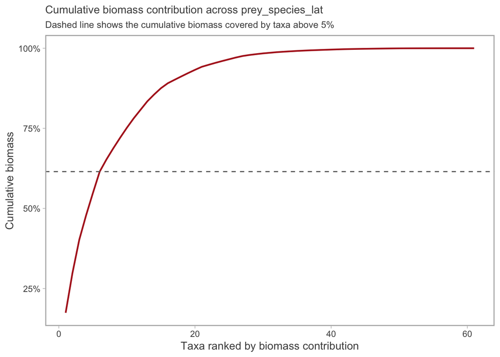

```r
plot_taxon_cumulative_biomass
```

## Group low-contribution taxa into Other

This section keeps the dominant taxa and collapses the rest into `Other`.

```r
# Replace low-contribution taxa with Other.
diet_rows_grouped <- diet_rows_main |>
  mutate(taxon = if_else(taxon %in% taxon_keep, taxon, "Other")) |>
  summarise(biomass_kg = sum(biomass_kg, na.rm = TRUE), .by = c(sample_id, taxon))

# Recalculate support after aggregation.
taxon_support_grouped <- diet_rows_grouped |>
  summarise(
    total_biomass_kg = sum(biomass_kg, na.rm = TRUE),
    n_samples_present = n_distinct(sample_id),
    .by = taxon
  ) |>
  arrange(desc(total_biomass_kg)) |>
  mutate(relative_biomass = total_biomass_kg / sum(total_biomass_kg))

taxon_levels <- c(setdiff(taxon_support_grouped$taxon, "Other"), "Other")

# Expand to every sample x taxon combination so that absences become explicit zeros.
year_center <- mean(sample_meta_main$year, na.rm = TRUE)
utm_zone <- floor((median(sample_meta_main$lon, na.rm = TRUE) + 180) / 6) + 1
utm_crs <- paste0("+proj=utm +zone=", utm_zone, " +datum=WGS84 +units=m")

diet_model <- sample_meta_main |>
  select(sample_id, year, month, quarter, lat, lon, collection_method, colony, sum_biomass_kg) |>
  expand_grid(taxon = taxon_levels) |>
  left_join(diet_rows_grouped, by = c("sample_id", "taxon")) |>
  mutate(
    biomass_kg = coalesce(biomass_kg, 0),

    # This is the within-seal diet proportion.
    prop = if_else(sum_biomass_kg > 0, biomass_kg / sum_biomass_kg, 0),

    # ZOIB step 1 from the vignette:
    # y_zero is 1 when the taxon proportion is exactly zero.
    y_zero = if_else(prop == 0, 1, 0),

    # ZOIB step 2 from the vignette:
    # y_one is only defined for non-zero observations.
    y_one = ifelse(prop == 1, 1, ifelse(prop < 1 & prop != 0, 0, NA)),

    # ZOIB step 3 from the vignette:
    # y_proportion keeps only the values strictly between 0 and 1.
    y_proportion = ifelse(prop < 1 & prop > 0, prop, NA),

    year_ct = year - year_center,
    collection_method = factor(collection_method, levels = method_keep),
    taxon = factor(taxon, levels = taxon_levels),
    year_f = factor(year)
  ) |>
  add_utm_columns(ll_names = c("lon", "lat"))

# Check how much of the response is zero, one, or strictly between 0 and 1.
diet_model |>
  summarise(
    n_samples = n_distinct(sample_id),
    n_rows = n(),
    n_taxa = n_distinct(taxon),
    prop_zero = mean(prop == 0),
    prop_one = mean(prop == 1),
    prop_middle = mean(prop > 0 & prop < 1)
  )
```

```
# A tibble: 1 x 6
  n_samples n_rows n_taxa prop_zero prop_one prop_middle
      <int>  <int>  <int>     <dbl>    <dbl>       <dbl>
1       829   5803      7     0.652   0.0431       0.305
```

## Support diagnostics after aggregation

This section shows the taxa that are actually entering the proportion model.

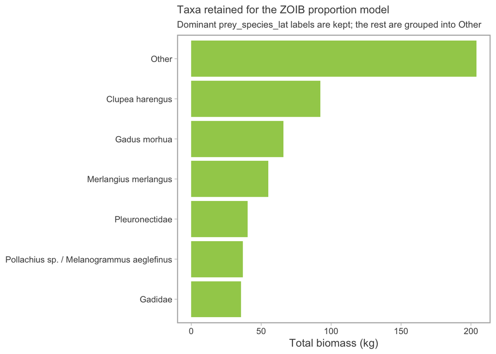

```r
taxon_component_support <- diet_model |>
  summarise(
    total_prop = sum(prop, na.rm = TRUE),
    n_zero = sum(prop == 0),
    n_one = sum(prop == 1),
    n_middle = sum(prop > 0 & prop < 1),
    .by = taxon
  )

plot_taxon_support_grouped <- taxon_support_grouped |>
  mutate(taxon = fct_reorder(as.character(taxon), total_biomass_kg)) |>
  ggplot(aes(total_biomass_kg, taxon)) +
  geom_col(fill = "darkolivegreen3") +
  labs(
    title = "Taxa retained for the ZOIB proportion model",
    subtitle = "Dominant prey_species_lat labels are kept; the rest are grouped into Other",
    x = "Total biomass (kg)",
    y = NULL
  )

plot_boundary_mass <- taxon_component_support |>
  transmute(
    taxon,
    zero_rate = n_zero / (n_zero + n_one + n_middle),
    one_rate = n_one / (n_zero + n_one + n_middle),
    middle_rate = n_middle / (n_zero + n_one + n_middle)
  ) |>
  pivot_longer(cols = c(zero_rate, one_rate,middle_rate), names_to = "component", values_to = "rate") |>
  ggplot(aes(rate, fct_reorder(as.character(taxon), rate), fill = component)) +
  geom_col(position = "dodge") +
  scale_x_continuous(labels = scales::percent_format(accuracy = 1)) +
  labs(
    title = "Zero, one and middle mass by retained taxon",
    x = "Rate",
    y = NULL,
    fill = NULL
  )

plot_taxon_support_grouped
```

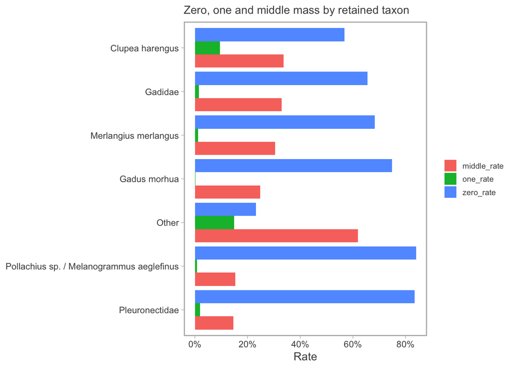

```r
plot_boundary_mass
```

## Quick north-south check in the observed data

This is a simple empirical check before model-based maps. It asks whether some taxa are more common in the north or south part of the study area.

```r
# Split the study area into a simple north and south half using the median latitude.
lat_split <- median(sample_meta_main$lat, na.rm = TRUE)

north_south_summary <- diet_model |>
  filter(as.character(taxon) != "Other") |>
  mutate(region = if_else(lat >= lat_split, "north", "south")) |>
  summarise(
    mean_prop = mean(prop, na.rm = TRUE),
    prevalence = mean(prop > 0, na.rm = TRUE),
    .by = c(taxon, region)
  )

plot_north_south <- north_south_summary |>
  ggplot(aes(mean_prop, fct_reorder(as.character(taxon), mean_prop), fill = region)) +
  geom_col(position = "dodge") +
  scale_x_continuous(labels = scales::percent_format(accuracy = 1)) +
  labs(
    title = "Observed mean diet proportion in the north and south",
    subtitle = "This is a simple descriptive split at the median latitude",
    x = "Mean proportion",
    y = NULL,
    fill = NULL
  )

north_south_summary
```

```
# A tibble: 12 x 4
   taxon                                     region mean_prop prevalence
   <fct>                                     <chr>      <dbl>      <dbl>
 1 Clupea harengus                           south     0.259      0.462
 2 Gadus morhua                              south     0.0570     0.183
 3 Merlangius merlangus                      south     0.0717     0.259
 4 Pleuronectidae                            south     0.0486     0.175
 5 Pollachius sp. / Melanogrammus aeglefinus south     0.0290     0.0863
 6 Gadidae                                   south     0.0585     0.287
 7 Clupea harengus                           north     0.175      0.405
 8 Gadus morhua                              north     0.0946     0.313
 9 Merlangius merlangus                      north     0.104      0.370
10 Pleuronectidae                            north     0.0772     0.156
11 Pollachius sp. / Melanogrammus aeglefinus north     0.0676     0.228
12 Gadidae                                   north     0.0891     0.398
```

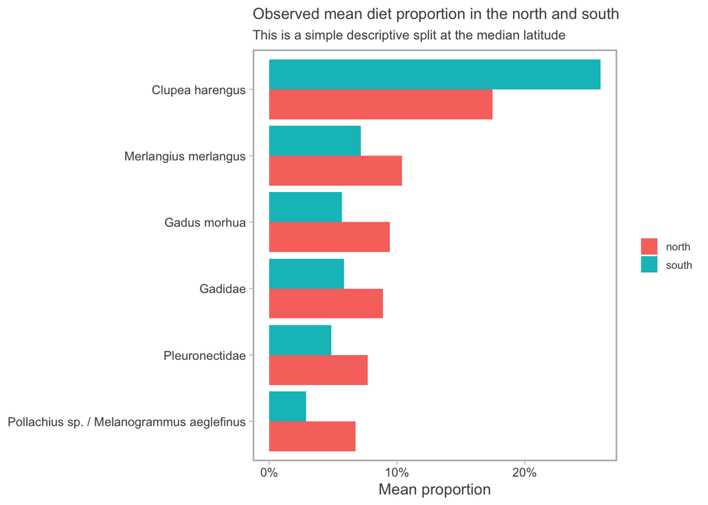

```r
plot_north_south
```

## Fit the three ZOIB sub-models

Following the sdmTMB ZOIB vignette, we fit three separate sub-models: a zero model (probability of absence), a one model (probability of full dominance), and a beta model (proportion when strictly between 0 and 1). We start simple and increase complexity step by step. The proportion sub-model mirrors the complexity range of the Tweedie model in 03b.

```r
# Split the data into the three parts needed by the vignette.
zero_data       <- diet_model
one_data        <- diet_model |> filter(!is.na(y_one))
proportion_data <- diet_model |> filter(!is.na(y_proportion))

# Mesh for the spatial proportion model (p5 only).
mesh <- make_mesh(proportion_data, xy_cols = c("X", "Y"), type = "cutoff", cutoff = mesh_cutoff_km)

# -----------------------------
# Zero component
# -----------------------------
# y_zero = 1 when taxon is absent, 0 when present.
# Minimum predictor: taxon. Build up by adding collection method, then their interaction.

z1 <- sdmTMB(
  y_zero ~ 0 + taxon,
  data    = zero_data,
  family  = binomial(link = "logit"),
  spatial = "off"
)

z2 <- sdmTMB(
  y_zero ~ 0 + taxon + collection_method,
  data    = zero_data,
  family  = binomial(link = "logit"),
  spatial = "off"
)

z3 <- sdmTMB(
  y_zero ~ 0 + taxon * collection_method,
  data    = zero_data,
  family  = binomial(link = "logit"),
  spatial = "off"
)

# -----------------------------
# One component
# -----------------------------
# y_one = 1 when taxon takes the entire sample, 0 when present but not exclusive.
# Exact ones are rare; keep this component simple: taxon baseline, then add method.

o1 <- sdmTMB(
  y_one ~ 0 + taxon,
  data    = one_data,
  family  = binomial(link = "logit"),
  spatial = "off"
)

o2 <- sdmTMB(
  y_one ~ 0 + taxon + collection_method,
  data    = one_data,
  family  = binomial(link = "logit"),
  spatial = "off"
)

# -----------------------------
# Proportion component
# -----------------------------
# Beta model for y_proportion values strictly between 0 and 1.
# Ladder spans from a simple non-spatial formula up to the Tweedie 03b complexity
# (collection_method * taxon + year_f * taxon + spatial field).

p1 <- sdmTMB(
  y_proportion ~ 0 + taxon,
  data    = proportion_data,
  family  = Beta(link = "logit"),
  spatial = "off"
)

p2 <- sdmTMB(
  y_proportion ~ 0 + taxon + collection_method,
  data    = proportion_data,
  family  = Beta(link = "logit"),
  spatial = "off"
)

p3 <- sdmTMB(
  y_proportion ~ 0 + taxon * collection_method,
  data    = proportion_data,
  family  = Beta(link = "logit"),
  spatial = "off"
)

# Add a year smooth per taxon — mirrors the temporal structure of the Tweedie 03b models.
# Using a continuous smooth rather than factor year avoids singularity with sparse taxon/year cells.
p4 <- sdmTMB(
  y_proportion ~ 0 + taxon + collection_method + s(year_ct, by = taxon),
  data    = proportion_data,
  family  = Beta(link = "logit"),
  spatial = "off"
)

# Same as p4 but adds a spatial random field — most complex candidate.
p5 <- sdmTMB(
  y_proportion ~ 0 + taxon + collection_method + s(year_ct, by = taxon),
  data    = proportion_data,
  family  = Beta(link = "logit"),
  mesh    = mesh,
  spatial = "on"
)
```

## AIC comparison of the sub-models

A quick AIC screening within each component. The three components are independent so we compare them separately, then combine the best from each.

```r
# Zero component AIC table.
zero_aic <- tibble(
  component = "zero",
  model     = c("z1_taxon", "z2_taxon_method", "z3_taxon_x_method"),
  aic       = c(AIC(z1), AIC(z2), AIC(z3))
) |>
  arrange(aic)

# One component AIC table.
one_aic <- tibble(
  component = "one",
  model     = c("o1_taxon", "o2_taxon_method"),
  aic       = c(AIC(o1), AIC(o2))
) |>
  arrange(aic)

# Proportion component AIC table.
proportion_aic <- tibble(
  component = "proportion",
  model     = c(
    "p1_taxon",
    "p2_taxon_method",
    "p3_taxon_x_method",
    "p4_taxon_method_year_smooth",
    "p5_taxon_method_year_smooth_spatial"
  ),
  aic = c(AIC(p1), AIC(p2), AIC(p3), AIC(p4), AIC(p5))
) |>
  arrange(aic)

zero_aic
```

```
# A tibble: 3 x 3
  component model               aic
  <chr>     <chr>             <dbl>
1 zero      z3_taxon_x_method 6411.
2 zero      z2_taxon_method   6520.
3 zero      z1_taxon          6557.
```

```r
one_aic
```

```
# A tibble: 2 x 3
  component model             aic
  <chr>     <chr>           <dbl>
1 one       o2_taxon_method 1344.
2 one       o1_taxon        1381.
```

```r
proportion_aic
```

```
# A tibble: 5 x 3
  component  model                                  aic
  <chr>      <chr>                                <dbl>
1 proportion p4_taxon_method_year_smooth         -1030.
2 proportion p5_taxon_method_year_smooth_spatial -1026.
3 proportion p3_taxon_x_method                   -1004.
4 proportion p2_taxon_method                      -977.
5 proportion p1_taxon                             -967.
```

## Combine predictions from the best sub-models

This section combines the three fitted parts exactly as in the vignette.

```r
# Identify the best model name in each sub-model table.
best_zero_name       <- zero_aic       |> slice_head(n = 1) |> pull(model)
best_one_name        <- one_aic        |> slice_head(n = 1) |> pull(model)
best_proportion_name <- proportion_aic |> slice_head(n = 1) |> pull(model)

# Pull out the corresponding fitted object.
best_zero <- switch(best_zero_name,
  z1_taxon         = z1,
  z2_taxon_method  = z2,
  z3_taxon_x_method = z3
)

best_one <- switch(best_one_name,
  o1_taxon        = o1,
  o2_taxon_method = o2
)

best_proportion <- switch(best_proportion_name,
  p1_taxon                              = p1,
  p2_taxon_method                       = p2,
  p3_taxon_x_method                     = p3,
  p4_taxon_method_year_smooth           = p4,
  p5_taxon_method_year_smooth_spatial   = p5
)

# Build a simple prediction grid over year, taxon, and sampling method.
# These predictions use one representative location, so they show temporal and method effects
# but they do not show spatial gradients.
pred_grid <- expand_grid(
  year = sort(unique(diet_model$year)),
  taxon = factor(taxon_levels, levels = levels(diet_model$taxon)),
  collection_method = factor(method_keep, levels = levels(diet_model$collection_method))
) |>
  mutate(
    year_ct = year - year_center,
    year_f = factor(year, levels = levels(diet_model$year_f)),

    # Give the spatial model one representative location when needed.
    X = median(diet_model$X, na.rm = TRUE),
    Y = median(diet_model$Y, na.rm = TRUE)
  )

# Predict each part of the ZOIB on the response scale.
pred_grid$p0 <- plogis(as.numeric(predict(best_zero,       newdata = pred_grid, re_form = NA)$est))
pred_grid$p1 <- plogis(as.numeric(predict(best_one,        newdata = pred_grid, re_form = NA)$est))
pred_grid$mu <- plogis(as.numeric(predict(best_proportion, newdata = pred_grid, re_form = NA)$est))

# Combine the three parts exactly as in the vignette.
pred_grid <- pred_grid |>
  mutate(expected_prop = (1 - p0) * (p1 + (1 - p1) * mu))

plot_expected_prop <- pred_grid |>
  ggplot(aes(year, expected_prop, colour = collection_method)) +
  geom_line(linewidth = 0.8) +
  facet_wrap(~ taxon, scales = "free_y") +
  scale_y_continuous(labels = scales::percent_format(accuracy = 1)) +
  labs(
    title = "Expected diet proportion by retained taxon and sampling type",
    subtitle = paste(
      "Best sub-models:",
      best_zero_name,
      "/",
      best_one_name,
      "/",
      best_proportion_name
    ),
    x = "Year",
    y = "Expected proportion",
    colour = "Method"
  )

pred_grid
```

```
# A tibble: 182 x 11
    year taxon  collection_method year_ct year_f     X     Y    p0      p1    mu
   <int> <fct>  <fct>               <dbl> <fct>  <dbl> <dbl> <dbl>   <dbl> <dbl>
 1  2013 Clupe~ Faeces              -6.58 2013    639. 6459. 0.713 0.329   0.527
 2  2013 Clupe~ Hunt                -6.58 2013    639. 6459. 0.414 0.164   0.478
 3  2013 Gadus~ Faeces              -6.58 2013    639. 6459. 0.813 0.0152  0.399
 4  2013 Gadus~ Hunt                -6.58 2013    639. 6459. 0.681 0.00614 0.353
 5  2013 Merla~ Faeces              -6.58 2013    639. 6459. 0.687 0.0533  0.342
 6  2013 Merla~ Hunt                -6.58 2013    639. 6459. 0.678 0.0221  0.299
 7  2013 Pleur~ Faeces              -6.58 2013    639. 6459. 0.766 0.138   0.393
 8  2013 Pleur~ Hunt                -6.58 2013    639. 6459. 0.908 0.0602  0.347
 9  2013 Polla~ Faeces              -6.58 2013    639. 6459. 0.907 0.0759  0.410
10  2013 Polla~ Hunt                -6.58 2013    639. 6459. 0.768 0.0319  0.363
# i 172 more rows
# i 1 more variable: expected_prop <dbl>
```

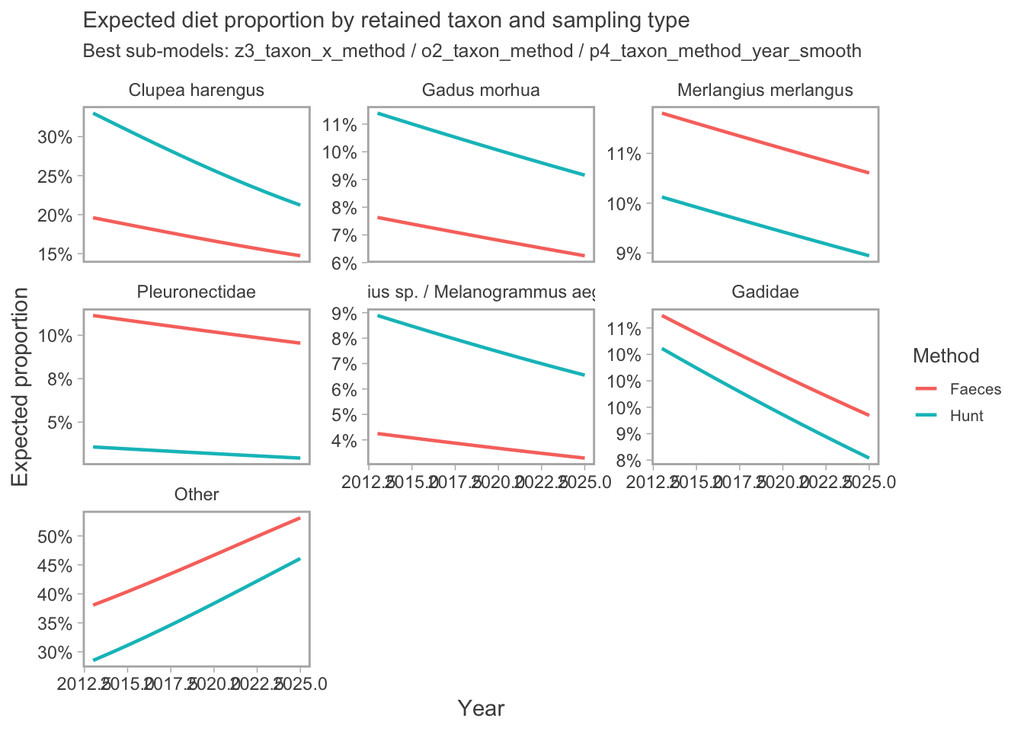

```r
plot_expected_prop
```

## Part 2: Predict diet proportions in space and time

We focus on cod (*Gadus morhua*) and herring (*Clupea harengus*), the two taxa with enough spatial coverage to support map predictions. For each species we fit three separate ZOIB sub-models (zero, one, proportion), then combine them using the same formula as Part 1.

## Prediction grid

```r
# Convex-hull grid over the observation area, covering all years.
# X and Y are in km (sdmTMB default); we convert to metres only at the plotting stage.
d <- diet_model

hull_idx  <- chull(d$X, d$Y)
hull_coords <- cbind(d$X[hull_idx], d$Y[hull_idx])
hull_coords <- rbind(hull_coords, hull_coords[1, ])

sp_poly <- sp::SpatialPolygons(
  list(sp::Polygons(list(sp::Polygon(hull_coords)), ID = 1))
)
sp_poly_df <- sp::SpatialPolygonsDataFrame(sp_poly, data = data.frame(ID = 1))

grid_base <- expand.grid(
  X    = seq(min(d$X), max(d$X), map_cell_width_km),
  Y    = seq(min(d$Y), max(d$Y), map_cell_width_km),
  year = sort(unique(d$year))
)

sp::coordinates(grid_base) <- c("X", "Y")
inside   <- !is.na(sp::over(grid_base, as(sp_poly_df, "SpatialPolygons")))
grid_base <- grid_base[inside, ]

pred_grid <- as.data.frame(grid_base) |>
  mutate(
    collection_method = factor("Hunt", levels = levels(diet_model$collection_method)),
    year_ct = year - year_center,
    year_f  = factor(year, levels = levels(diet_model$year_f))
  )

# Coastline for maps (same CRS as the data: UTM 32N).
land <- ne_countries(scale = "large", returnclass = "sf") |>
  st_transform(32632)
```

## Species-specific ZOIB models

For each species we fit:

- A **zero** sub-model: probability the species is absent from the sample.
- A **one** sub-model: probability the species dominates the entire sample.
- A **proportion** sub-model with a spatial field for map prediction.
- A **proportion** sub-model with a spatiotemporal (IID) field for year-by-year maps.

```r
# --- Cod ---

cod_zero_data <- zero_data       |> filter(as.character(taxon) == "Gadus morhua")
cod_one_data  <- one_data        |> filter(as.character(taxon) == "Gadus morhua")
cod_prop_data <- proportion_data |> filter(as.character(taxon) == "Gadus morhua")

cod_mesh <- make_mesh(cod_prop_data, xy_cols = c("X", "Y"), type = "cutoff", cutoff = mesh_cutoff_km)

cod_zero_mod <- sdmTMB(
  y_zero ~ collection_method,
  data    = cod_zero_data,
  family  = binomial(link = "logit"),
  spatial = "off"
)

cod_one_mod <- sdmTMB(
  y_one ~ collection_method,
  data    = cod_one_data,
  family  = binomial(link = "logit"),
  spatial = "off"
)

# Spatial-only proportion model: time-averaged spatial pattern.
cod_prop_spatial <- sdmTMB(
  y_proportion ~ collection_method,
  data    = cod_prop_data,
  family  = Beta(link = "logit"),
  mesh    = cod_mesh,
  spatial = "on"
)

# Spatiotemporal proportion model: spatial pattern allowed to vary by year.
cod_prop_st <- sdmTMB(
  y_proportion ~ collection_method,
  data           = cod_prop_data,
  family         = Beta(link = "logit"),
  mesh           = cod_mesh,
  spatial        = "on",
  time           = "year",
  spatiotemporal = "iid"
)

cod_years <- sort(unique(cod_prop_data$year))

# --- Herring ---

her_zero_data <- zero_data       |> filter(as.character(taxon) == "Clupea harengus")
her_one_data  <- one_data        |> filter(as.character(taxon) == "Clupea harengus")
her_prop_data <- proportion_data |> filter(as.character(taxon) == "Clupea harengus")

her_mesh <- make_mesh(her_prop_data, xy_cols = c("X", "Y"), type = "cutoff", cutoff = mesh_cutoff_km)

her_zero_mod <- sdmTMB(
  y_zero ~ collection_method,
  data    = her_zero_data,
  family  = binomial(link = "logit"),
  spatial = "off"
)

her_one_mod <- sdmTMB(
  y_one ~ collection_method,
  data    = her_one_data,
  family  = binomial(link = "logit"),
  spatial = "off"
)

her_prop_spatial <- sdmTMB(
  y_proportion ~ collection_method,
  data    = her_prop_data,
  family  = Beta(link = "logit"),
  mesh    = her_mesh,
  spatial = "on"
)

her_prop_st <- sdmTMB(
  y_proportion ~ collection_method,
  data           = her_prop_data,
  family         = Beta(link = "logit"),
  mesh           = her_mesh,
  spatial        = "on",
  time           = "year",
  spatiotemporal = "iid"
)

her_years <- sort(unique(her_prop_data$year))
```

## Temporal trends (non-spatial)

Predict over all years at the median location using the non-spatial sub-models. This shows the temporal trend in expected diet proportion for each sampling method.

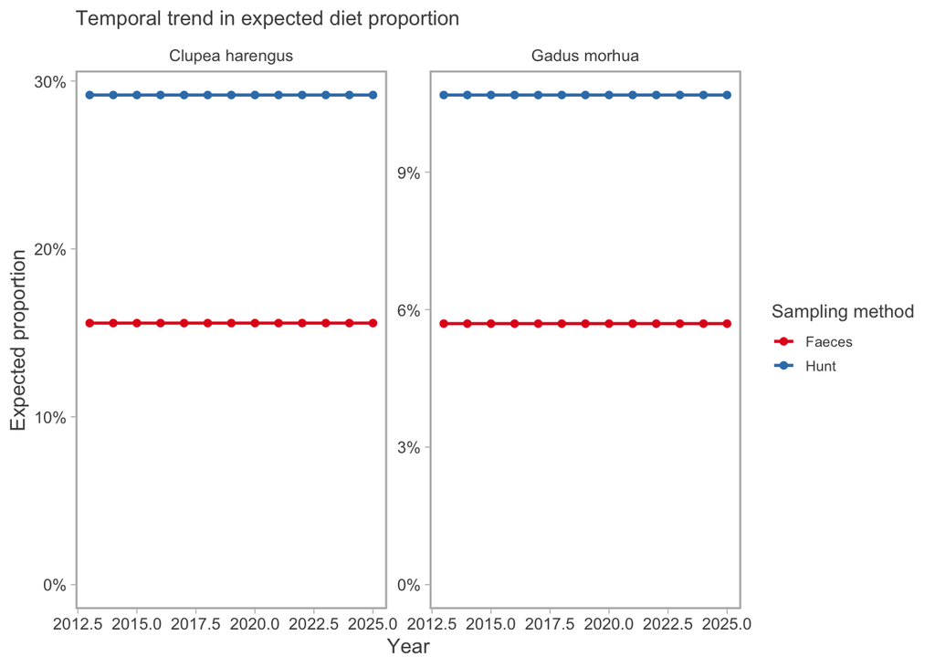

```r
# One row per year × method combination; fixed spatial location.
trend_grid <- expand_grid(
  year              = sort(unique(diet_model$year)),
  collection_method = factor(method_keep, levels = levels(diet_model$collection_method))
) |>
  mutate(
    year_ct = year - year_center,
    year_f  = factor(year, levels = levels(diet_model$year_f)),
    X       = median(diet_model$X, na.rm = TRUE),
    Y       = median(diet_model$Y, na.rm = TRUE)
  )

# Cod
trend_cod <- trend_grid |>
  mutate(
    p0            = plogis(predict(cod_zero_mod, newdata = trend_grid, re_form = NA)$est),
    p1            = plogis(predict(cod_one_mod,  newdata = trend_grid, re_form = NA)$est),
    mu            = plogis(predict(cod_prop_spatial, newdata = trend_grid, re_form = NA)$est),
    expected_prop = (1 - p0) * (p1 + (1 - p1) * mu),
    taxon         = "Gadus morhua"
  )

# Herring
trend_her <- trend_grid |>
  mutate(
    p0            = plogis(predict(her_zero_mod, newdata = trend_grid, re_form = NA)$est),
    p1            = plogis(predict(her_one_mod,  newdata = trend_grid, re_form = NA)$est),
    mu            = plogis(predict(her_prop_spatial, newdata = trend_grid, re_form = NA)$est),
    expected_prop = (1 - p0) * (p1 + (1 - p1) * mu),
    taxon         = "Clupea harengus"
  )

trend_both <- bind_rows(trend_cod, trend_her)

trend_both |>
  ggplot(aes(year, expected_prop, colour = collection_method)) +
  geom_line(linewidth = 0.8) +
  geom_point(size = 1.5) +
  scale_y_continuous(labels = scales::percent_format(accuracy = 1), limits = c(0, NA)) +
  scale_colour_brewer(palette = "Set1") +
  facet_wrap(~taxon, scales = "free_y") +
  labs(
    title   = "Temporal trend in expected diet proportion",
    x       = "Year",
    y       = "Expected proportion",
    colour  = "Sampling method"
  )
```

## Time-averaged spatial map

The spatial-only proportion model averages over time and shows the broad spatial structure in diet composition.

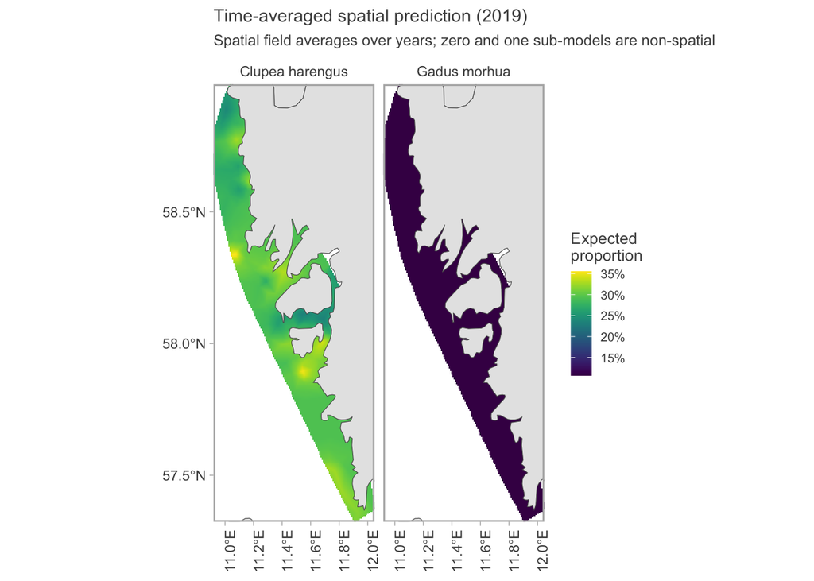

```r
# Use a single representative year for the spatial-only prediction.
map_year <- 2019

pg_s <- pred_grid |> filter(year == map_year)

cod_pg_s <- pg_s |>
  mutate(
    p0            = plogis(predict(cod_zero_mod,     newdata = pg_s)$est),
    p1            = plogis(predict(cod_one_mod,      newdata = pg_s)$est),
    mu            = plogis(predict(cod_prop_spatial, newdata = pg_s)$est),
    expected_prop = (1 - p0) * (p1 + (1 - p1) * mu),
    taxon         = "Gadus morhua"
  )

her_pg_s <- pg_s |>
  mutate(
    p0            = plogis(predict(her_zero_mod,     newdata = pg_s)$est),
    p1            = plogis(predict(her_one_mod,      newdata = pg_s)$est),
    mu            = plogis(predict(her_prop_spatial, newdata = pg_s)$est),
    expected_prop = (1 - p0) * (p1 + (1 - p1) * mu),
    taxon         = "Clupea harengus"
  )

pg_spatial <- bind_rows(cod_pg_s, her_pg_s)

pg_spatial |>
  ggplot(aes(X * 1000, Y * 1000, fill = expected_prop)) +
  geom_raster() +
  geom_sf(data = land, fill = "grey90", linewidth = 0.2, inherit.aes = FALSE) +
  viridis::scale_fill_viridis(labels = scales::percent_format(accuracy = 1)) +
  coord_sf(
    crs  = 32632,
    xlim = range(pg_spatial$X * 1000),
    ylim = range(pg_spatial$Y * 1000),
    expand = FALSE
  ) +
  facet_wrap(~taxon, ncol = 2) +
  labs(
    title    = paste0("Time-averaged spatial prediction (", map_year, ")"),
    subtitle = "Spatial field averages over years; zero and one sub-models are non-spatial",
    x        = NULL,
    y        = NULL,
    fill     = "Expected\nproportion"
  ) +
  theme(axis.text.x = element_text(angle = 90))
```

## Spatiotemporal maps

The spatiotemporal model lets the spatial field vary by year (IID random fields). We predict for all observed years and show three representative snapshots.

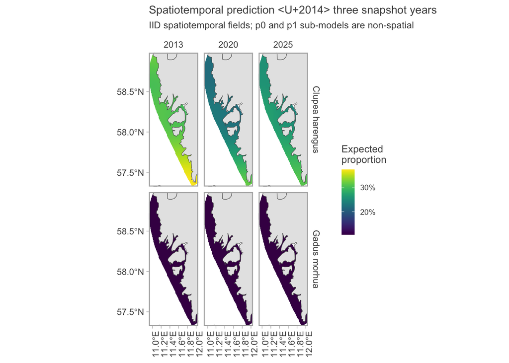

```r
# Predict over all observed years for each species.
cod_pg_st <- pred_grid |>
  filter(year %in% cod_years) |>
  mutate(
    p0            = plogis(predict(cod_zero_mod, newdata = filter(pred_grid, year %in% cod_years))$est),
    p1            = plogis(predict(cod_one_mod,  newdata = filter(pred_grid, year %in% cod_years))$est),
    mu            = plogis(predict(cod_prop_st,  newdata = filter(pred_grid, year %in% cod_years))$est),
    expected_prop = (1 - p0) * (p1 + (1 - p1) * mu),
    taxon         = "Gadus morhua"
  )

her_pg_st <- pred_grid |>
  filter(year %in% her_years) |>
  mutate(
    p0            = plogis(predict(her_zero_mod, newdata = filter(pred_grid, year %in% her_years))$est),
    p1            = plogis(predict(her_one_mod,  newdata = filter(pred_grid, year %in% her_years))$est),
    mu            = plogis(predict(her_prop_st,  newdata = filter(pred_grid, year %in% her_years))$est),
    expected_prop = (1 - p0) * (p1 + (1 - p1) * mu),
    taxon         = "Clupea harengus"
  )

pg_st <- bind_rows(cod_pg_st, her_pg_st)

# Three representative years: first, middle, last of the time series.
snap_years <- c(min(cod_years), median(cod_years) |> round(), max(cod_years))

pg_st |>
  filter(year %in% snap_years) |>
  ggplot(aes(X * 1000, Y * 1000, fill = expected_prop)) +
  geom_raster() +
  geom_sf(data = land, fill = "grey90", linewidth = 0.2, inherit.aes = FALSE) +
  viridis::scale_fill_viridis(labels = scales::percent_format(accuracy = 1)) +
  coord_sf(
    crs  = 32632,
    xlim = range(pg_st$X * 1000),
    ylim = range(pg_st$Y * 1000),
    expand = FALSE
  ) +
  facet_grid(taxon ~ year) +
  labs(
    title    = "Spatiotemporal prediction — three snapshot years",
    subtitle = "IID spatiotemporal fields; p0 and p1 sub-models are non-spatial",
    x        = NULL,
    y        = NULL,
    fill     = "Expected\nproportion"
  ) +
  theme(axis.text.x = element_text(angle = 90))
```

## ZOIB component breakdown

Decompose the final prediction into its three parts to understand what drives the spatial pattern.

[figure not shown]

```r
# Use the time-averaged spatial prediction for the breakdown year.
breakdown_grid <- pred_grid |> filter(year == map_year)

component_long <- bind_rows(
  breakdown_grid |>
    mutate(
      p0    = plogis(predict(cod_zero_mod,     newdata = breakdown_grid)$est),
      p1    = plogis(predict(cod_one_mod,      newdata = breakdown_grid)$est),
      mu    = plogis(predict(cod_prop_spatial, newdata = breakdown_grid)$est),
      taxon = "Gadus morhua"
    ),
  breakdown_grid |>
    mutate(
      p0    = plogis(predict(her_zero_mod,     newdata = breakdown_grid)$est),
      p1    = plogis(predict(her_one_mod,      newdata = breakdown_grid)$est),
      mu    = plogis(predict(her_prop_spatial, newdata = breakdown_grid)$est),
      taxon = "Clupea harengus"
    )
) |>
  mutate(expected_prop = (1 - p0) * (p1 + (1 - p1) * mu)) |>
  pivot_longer(
    cols      = c(p0, mu, expected_prop),
    names_to  = "component",
    values_to = "value"
  ) |>
  mutate(component = recode(component,
    p0            = "P(absence)",
    mu            = "Positive proportion",
    expected_prop = "Expected proportion"
  ))

component_long |>
  ggplot(aes(X * 1000, Y * 1000, fill = value)) +
  geom_raster() +
  geom_sf(data = land, fill = "grey90", linewidth = 0.2, inherit.aes = FALSE) +
  viridis::scale_fill_viridis(labels = scales::percent_format(accuracy = 1)) +
  coord_sf(
    crs  = 32632,
    xlim = range(breakdown_grid$X * 1000),
    ylim = range(breakdown_grid$Y * 1000),
    expand = FALSE
  ) +
  facet_grid(taxon ~ component) +
  labs(
    title    = paste0("ZOIB component breakdown (", map_year, ")"),
    subtitle = "Left: probability of absence. Centre: positive proportion. Right: combined expected proportion.",
    x        = NULL,
    y        = NULL,
    fill     = "Value"
  ) +
  theme(axis.text.x = element_text(angle = 90))
```